# Risk Factor Analysis

## Outcome Variable

**Outcome Variable:** stunted

## Predictor Variables

**Intervention Variable:** birthwt

**Adjustment Set:**

unadjusted

## Stratifying Variables

The analysis was stratified on these variable(s):

- agecat
- studyid
- country

## Data Summary

| agecat | studyid | country | A | n | nA | nAY0 | nAY1 |
| --- | --- | --- | --- | --- | --- | --- | --- |
| Birth | ki0047075b-MAL-ED | BANGLADESH | >=0 | 257 | 34 | 34 | 0 |
| Birth | ki0047075b-MAL-ED | BANGLADESH | <-3 | 257 | 7 | 0 | 7 |
| Birth | ki0047075b-MAL-ED | BANGLADESH | [-3–2) | 257 | 38 | 16 | 22 |
| Birth | ki0047075b-MAL-ED | BANGLADESH | [-2–1) | 257 | 96 | 82 | 14 |
| Birth | ki0047075b-MAL-ED | BANGLADESH | [-1-0) | 257 | 82 | 78 | 4 |
| Birth | ki0047075b-MAL-ED | BRAZIL | >=0 | 191 | 111 | 106 | 5 |
| Birth | ki0047075b-MAL-ED | BRAZIL | <-3 | 191 | 0 | 0 | 0 |
| Birth | ki0047075b-MAL-ED | BRAZIL | [-3–2) | 191 | 6 | 2 | 4 |
| Birth | ki0047075b-MAL-ED | BRAZIL | [-2–1) | 191 | 19 | 13 | 6 |
| Birth | ki0047075b-MAL-ED | BRAZIL | [-1-0) | 191 | 55 | 49 | 6 |
| Birth | ki0047075b-MAL-ED | INDIA | >=0 | 206 | 40 | 40 | 0 |
| Birth | ki0047075b-MAL-ED | INDIA | <-3 | 206 | 2 | 0 | 2 |
| Birth | ki0047075b-MAL-ED | INDIA | [-3–2) | 206 | 21 | 11 | 10 |
| Birth | ki0047075b-MAL-ED | INDIA | [-2–1) | 206 | 68 | 51 | 17 |
| Birth | ki0047075b-MAL-ED | INDIA | [-1-0) | 206 | 75 | 71 | 4 |
| Birth | ki0047075b-MAL-ED | NEPAL | >=0 | 173 | 32 | 32 | 0 |
| Birth | ki0047075b-MAL-ED | NEPAL | <-3 | 173 | 4 | 0 | 4 |
| Birth | ki0047075b-MAL-ED | NEPAL | [-3–2) | 173 | 12 | 5 | 7 |
| Birth | ki0047075b-MAL-ED | NEPAL | [-2–1) | 173 | 40 | 36 | 4 |
| Birth | ki0047075b-MAL-ED | NEPAL | [-1-0) | 173 | 85 | 82 | 3 |
| Birth | ki0047075b-MAL-ED | PERU | >=0 | 287 | 90 | 90 | 0 |
| Birth | ki0047075b-MAL-ED | PERU | <-3 | 287 | 4 | 0 | 4 |
| Birth | ki0047075b-MAL-ED | PERU | [-3–2) | 287 | 9 | 2 | 7 |
| Birth | ki0047075b-MAL-ED | PERU | [-2–1) | 287 | 42 | 24 | 18 |
| Birth | ki0047075b-MAL-ED | PERU | [-1-0) | 287 | 142 | 137 | 5 |
| Birth | ki0047075b-MAL-ED | SOUTH AFRICA | >=0 | 262 | 91 | 91 | 0 |
| Birth | ki0047075b-MAL-ED | SOUTH AFRICA | <-3 | 262 | 5 | 2 | 3 |
| Birth | ki0047075b-MAL-ED | SOUTH AFRICA | [-3–2) | 262 | 11 | 4 | 7 |
| Birth | ki0047075b-MAL-ED | SOUTH AFRICA | [-2–1) | 262 | 39 | 30 | 9 |
| Birth | ki0047075b-MAL-ED | SOUTH AFRICA | [-1-0) | 262 | 116 | 107 | 9 |

[output cut: 750 more lines]

The following strata were considered:

- agecat: 12 months, studyid: ki0047075b-MAL-ED, country: BANGLADESH
- agecat: 12 months, studyid: ki0047075b-MAL-ED, country: BRAZIL
- agecat: 12 months, studyid: ki0047075b-MAL-ED, country: INDIA
- agecat: 12 months, studyid: ki0047075b-MAL-ED, country: NEPAL
- agecat: 12 months, studyid: ki0047075b-MAL-ED, country: PERU
- agecat: 12 months, studyid: ki0047075b-MAL-ED, country: SOUTH AFRICA
- agecat: 12 months, studyid: ki0047075b-MAL-ED, country: TANZANIA, UNITED REPUBLIC OF
- agecat: 12 months, studyid: ki1000108-CMC-V-BCS-2002, country: INDIA
- agecat: 12 months, studyid: ki1000108-IRC, country: INDIA
- agecat: 12 months, studyid: ki1000109-EE, country: PAKISTAN
- agecat: 12 months, studyid: ki1000109-ResPak, country: PAKISTAN
- agecat: 12 months, studyid: ki1017093-NIH-Birth, country: BANGLADESH
- agecat: 12 months, studyid: ki1017093b-PROVIDE, country: BANGLADESH
- agecat: 12 months, studyid: ki1017093c-NIH-Crypto, country: BANGLADESH
- agecat: 12 months, studyid: ki1066203-TanzaniaChild2, country: TANZANIA, UNITED REPUBLIC OF
- agecat: 12 months, studyid: ki1101329-Keneba, country: GAMBIA
- agecat: 12 months, studyid: ki1114097-CMIN, country: BRAZIL
- agecat: 12 months, studyid: ki1114097-CMIN, country: PERU
- agecat: 12 months, studyid: ki1114097-CONTENT, country: PERU
- agecat: 12 months, studyid: ki1126311-ZVITAMBO, country: ZIMBABWE
- agecat: 12 months, studyid: ki1135781-COHORTS, country: GUATEMALA
- agecat: 12 months, studyid: ki1135781-COHORTS, country: INDIA
- agecat: 12 months, studyid: ki1135781-COHORTS, country: PHILIPPINES
- agecat: 18 months, studyid: ki0047075b-MAL-ED, country: BANGLADESH
- agecat: 18 months, studyid: ki0047075b-MAL-ED, country: BRAZIL
- agecat: 18 months, studyid: ki0047075b-MAL-ED, country: INDIA
- agecat: 18 months, studyid: ki0047075b-MAL-ED, country: NEPAL
- agecat: 18 months, studyid: ki0047075b-MAL-ED, country: PERU
- agecat: 18 months, studyid: ki0047075b-MAL-ED, country: SOUTH AFRICA
- agecat: 18 months, studyid: ki0047075b-MAL-ED, country: TANZANIA, UNITED REPUBLIC OF
- agecat: 18 months, studyid: ki1000108-CMC-V-BCS-2002, country: INDIA
- agecat: 18 months, studyid: ki1000108-IRC, country: INDIA
- agecat: 18 months, studyid: ki1000109-EE, country: PAKISTAN
- agecat: 18 months, studyid: ki1000109-ResPak, country: PAKISTAN
- agecat: 18 months, studyid: ki1017093-NIH-Birth, country: BANGLADESH
- agecat: 18 months, studyid: ki1017093b-PROVIDE, country: BANGLADESH
- agecat: 18 months, studyid: ki1017093c-NIH-Crypto, country: BANGLADESH
- agecat: 18 months, studyid: ki1066203-TanzaniaChild2, country: TANZANIA, UNITED REPUBLIC OF
- agecat: 18 months, studyid: ki1101329-Keneba, country: GAMBIA
- agecat: 18 months, studyid: ki1114097-CMIN, country: BRAZIL
- agecat: 18 months, studyid: ki1114097-CMIN, country: PERU
- agecat: 18 months, studyid: ki1114097-CONTENT, country: PERU
- agecat: 18 months, studyid: ki1126311-ZVITAMBO, country: ZIMBABWE
- agecat: 18 months, studyid: ki1135781-COHORTS, country: GUATEMALA
- agecat: 18 months, studyid: ki1135781-COHORTS, country: PHILIPPINES
- agecat: 24 months, studyid: ki0047075b-MAL-ED, country: BANGLADESH
- agecat: 24 months, studyid: ki0047075b-MAL-ED, country: BRAZIL
- agecat: 24 months, studyid: ki0047075b-MAL-ED, country: INDIA
- agecat: 24 months, studyid: ki0047075b-MAL-ED, country: NEPAL
- agecat: 24 months, studyid: ki0047075b-MAL-ED, country: PERU
- agecat: 24 months, studyid: ki0047075b-MAL-ED, country: SOUTH AFRICA
- agecat: 24 months, studyid: ki0047075b-MAL-ED, country: TANZANIA, UNITED REPUBLIC OF
- agecat: 24 months, studyid: ki1000108-CMC-V-BCS-2002, country: INDIA
- agecat: 24 months, studyid: ki1000108-IRC, country: INDIA
- agecat: 24 months, studyid: ki1017093-NIH-Birth, country: BANGLADESH
- agecat: 24 months, studyid: ki1017093b-PROVIDE, country: BANGLADESH
- agecat: 24 months, studyid: ki1017093c-NIH-Crypto, country: BANGLADESH
- agecat: 24 months, studyid: ki1066203-TanzaniaChild2, country: TANZANIA, UNITED REPUBLIC OF
- agecat: 24 months, studyid: ki1101329-Keneba, country: GAMBIA
- agecat: 24 months, studyid: ki1114097-CMIN, country: PERU
- agecat: 24 months, studyid: ki1114097-CONTENT, country: PERU
- agecat: 24 months, studyid: ki1126311-ZVITAMBO, country: ZIMBABWE
- agecat: 24 months, studyid: ki1135781-COHORTS, country: GUATEMALA
- agecat: 24 months, studyid: ki1135781-COHORTS, country: INDIA
- agecat: 24 months, studyid: ki1135781-COHORTS, country: PHILIPPINES
- agecat: 3 months, studyid: ki0047075b-MAL-ED, country: BANGLADESH
- agecat: 3 months, studyid: ki0047075b-MAL-ED, country: BRAZIL
- agecat: 3 months, studyid: ki0047075b-MAL-ED, country: INDIA
- agecat: 3 months, studyid: ki0047075b-MAL-ED, country: NEPAL
- agecat: 3 months, studyid: ki0047075b-MAL-ED, country: PERU
- agecat: 3 months, studyid: ki0047075b-MAL-ED, country: SOUTH AFRICA
- agecat: 3 months, studyid: ki0047075b-MAL-ED, country: TANZANIA, UNITED REPUBLIC OF
- agecat: 3 months, studyid: ki1000108-CMC-V-BCS-2002, country: INDIA
- agecat: 3 months, studyid: ki1000108-IRC, country: INDIA
- agecat: 3 months, studyid: ki1000109-EE, country: PAKISTAN
- agecat: 3 months, studyid: ki1000109-ResPak, country: PAKISTAN
- agecat: 3 months, studyid: ki1017093-NIH-Birth, country: BANGLADESH
- agecat: 3 months, studyid: ki1017093b-PROVIDE, country: BANGLADESH
- agecat: 3 months, studyid: ki1017093c-NIH-Crypto, country: BANGLADESH
- agecat: 3 months, studyid: ki1066203-TanzaniaChild2, country: TANZANIA, UNITED REPUBLIC OF
- agecat: 3 months, studyid: ki1101329-Keneba, country: GAMBIA
- agecat: 3 months, studyid: ki1114097-CMIN, country: BRAZIL
- agecat: 3 months, studyid: ki1114097-CMIN, country: PERU
- agecat: 3 months, studyid: ki1114097-CONTENT, country: PERU
- agecat: 3 months, studyid: ki1126311-ZVITAMBO, country: ZIMBABWE
- agecat: 3 months, studyid: ki1135781-COHORTS, country: GUATEMALA
- agecat: 3 months, studyid: ki1135781-COHORTS, country: INDIA
- agecat: 3 months, studyid: ki1135781-COHORTS, country: PHILIPPINES
- agecat: 6 months, studyid: ki0047075b-MAL-ED, country: BANGLADESH
- agecat: 6 months, studyid: ki0047075b-MAL-ED, country: BRAZIL
- agecat: 6 months, studyid: ki0047075b-MAL-ED, country: INDIA
- agecat: 6 months, studyid: ki0047075b-MAL-ED, country: NEPAL
- agecat: 6 months, studyid: ki0047075b-MAL-ED, country: PERU
- agecat: 6 months, studyid: ki0047075b-MAL-ED, country: SOUTH AFRICA
- agecat: 6 months, studyid: ki0047075b-MAL-ED, country: TANZANIA, UNITED REPUBLIC OF
- agecat: 6 months, studyid: ki1000108-CMC-V-BCS-2002, country: INDIA
- agecat: 6 months, studyid: ki1000108-IRC, country: INDIA
- agecat: 6 months, studyid: ki1000109-EE, country: PAKISTAN
- agecat: 6 months, studyid: ki1000109-ResPak, country: PAKISTAN
- agecat: 6 months, studyid: ki1017093-NIH-Birth, country: BANGLADESH
- agecat: 6 months, studyid: ki1017093b-PROVIDE, country: BANGLADESH
- agecat: 6 months, studyid: ki1017093c-NIH-Crypto, country: BANGLADESH
- agecat: 6 months, studyid: ki1066203-TanzaniaChild2, country: TANZANIA, UNITED REPUBLIC OF
- agecat: 6 months, studyid: ki1101329-Keneba, country: GAMBIA
- agecat: 6 months, studyid: ki1114097-CMIN, country: BRAZIL
- agecat: 6 months, studyid: ki1114097-CMIN, country: PERU
- agecat: 6 months, studyid: ki1114097-CONTENT, country: PERU
- agecat: 6 months, studyid: ki1126311-ZVITAMBO, country: ZIMBABWE
- agecat: 6 months, studyid: ki1135781-COHORTS, country: GUATEMALA
- agecat: 6 months, studyid: ki1135781-COHORTS, country: INDIA
- agecat: 6 months, studyid: ki1135781-COHORTS, country: PHILIPPINES
- agecat: 9 months, studyid: ki0047075b-MAL-ED, country: BANGLADESH
- agecat: 9 months, studyid: ki0047075b-MAL-ED, country: BRAZIL
- agecat: 9 months, studyid: ki0047075b-MAL-ED, country: INDIA
- agecat: 9 months, studyid: ki0047075b-MAL-ED, country: NEPAL
- agecat: 9 months, studyid: ki0047075b-MAL-ED, country: PERU
- agecat: 9 months, studyid: ki0047075b-MAL-ED, country: SOUTH AFRICA
- agecat: 9 months, studyid: ki0047075b-MAL-ED, country: TANZANIA, UNITED REPUBLIC OF
- agecat: 9 months, studyid: ki1000108-CMC-V-BCS-2002, country: INDIA
- agecat: 9 months, studyid: ki1000108-IRC, country: INDIA
- agecat: 9 months, studyid: ki1000109-EE, country: PAKISTAN
- agecat: 9 months, studyid: ki1000109-ResPak, country: PAKISTAN
- agecat: 9 months, studyid: ki1017093-NIH-Birth, country: BANGLADESH
- agecat: 9 months, studyid: ki1017093b-PROVIDE, country: BANGLADESH
- agecat: 9 months, studyid: ki1017093c-NIH-Crypto, country: BANGLADESH
- agecat: 9 months, studyid: ki1066203-TanzaniaChild2, country: TANZANIA, UNITED REPUBLIC OF
- agecat: 9 months, studyid: ki1101329-Keneba, country: GAMBIA
- agecat: 9 months, studyid: ki1114097-CMIN, country: BRAZIL
- agecat: 9 months, studyid: ki1114097-CMIN, country: PERU
- agecat: 9 months, studyid: ki1114097-CONTENT, country: PERU
- agecat: 9 months, studyid: ki1126311-ZVITAMBO, country: ZIMBABWE
- agecat: 9 months, studyid: ki1135781-COHORTS, country: GUATEMALA
- agecat: 9 months, studyid: ki1135781-COHORTS, country: INDIA
- agecat: 9 months, studyid: ki1135781-COHORTS, country: PHILIPPINES
- agecat: Birth, studyid: ki0047075b-MAL-ED, country: BANGLADESH
- agecat: Birth, studyid: ki0047075b-MAL-ED, country: BRAZIL
- agecat: Birth, studyid: ki0047075b-MAL-ED, country: INDIA
- agecat: Birth, studyid: ki0047075b-MAL-ED, country: NEPAL
- agecat: Birth, studyid: ki0047075b-MAL-ED, country: PERU
- agecat: Birth, studyid: ki0047075b-MAL-ED, country: SOUTH AFRICA
- agecat: Birth, studyid: ki0047075b-MAL-ED, country: TANZANIA, UNITED REPUBLIC OF
- agecat: Birth, studyid: ki1000108-CMC-V-BCS-2002, country: INDIA
- agecat: Birth, studyid: ki1000108-IRC, country: INDIA
- agecat: Birth, studyid: ki1000109-EE, country: PAKISTAN
- agecat: Birth, studyid: ki1000109-ResPak, country: PAKISTAN
- agecat: Birth, studyid: ki1017093-NIH-Birth, country: BANGLADESH
- agecat: Birth, studyid: ki1017093c-NIH-Crypto, country: BANGLADESH
- agecat: Birth, studyid: ki1101329-Keneba, country: GAMBIA
- agecat: Birth, studyid: ki1114097-CMIN, country: BANGLADESH
- agecat: Birth, studyid: ki1114097-CMIN, country: BRAZIL
- agecat: Birth, studyid: ki1114097-CMIN, country: PERU
- agecat: Birth, studyid: ki1114097-CONTENT, country: PERU
- agecat: Birth, studyid: ki1126311-ZVITAMBO, country: ZIMBABWE
- agecat: Birth, studyid: ki1135781-COHORTS, country: GUATEMALA
- agecat: Birth, studyid: ki1135781-COHORTS, country: INDIA
- agecat: Birth, studyid: ki1135781-COHORTS, country: PHILIPPINES

### Dropped Strata

Some strata were dropped due to rare outcomes:

- agecat: Birth, studyid: ki0047075b-MAL-ED, country: BANGLADESH
- agecat: Birth, studyid: ki0047075b-MAL-ED, country: BRAZIL
- agecat: Birth, studyid: ki0047075b-MAL-ED, country: INDIA
- agecat: Birth, studyid: ki0047075b-MAL-ED, country: NEPAL
- agecat: Birth, studyid: ki0047075b-MAL-ED, country: PERU
- agecat: Birth, studyid: ki0047075b-MAL-ED, country: SOUTH AFRICA
- agecat: Birth, studyid: ki0047075b-MAL-ED, country: TANZANIA, UNITED REPUBLIC OF
- agecat: Birth, studyid: ki1000108-CMC-V-BCS-2002, country: INDIA
- agecat: Birth, studyid: ki1000108-IRC, country: INDIA
- agecat: Birth, studyid: ki1000109-EE, country: PAKISTAN
- agecat: Birth, studyid: ki1000109-ResPak, country: PAKISTAN
- agecat: Birth, studyid: ki1017093-NIH-Birth, country: BANGLADESH
- agecat: Birth, studyid: ki1017093c-NIH-Crypto, country: BANGLADESH
- agecat: Birth, studyid: ki1101329-Keneba, country: GAMBIA
- agecat: Birth, studyid: ki1114097-CMIN, country: BANGLADESH
- agecat: Birth, studyid: ki1114097-CMIN, country: BRAZIL
- agecat: Birth, studyid: ki1114097-CMIN, country: PERU
- agecat: Birth, studyid: ki1114097-CONTENT, country: PERU
- agecat: Birth, studyid: ki1135781-COHORTS, country: GUATEMALA
- agecat: Birth, studyid: ki1135781-COHORTS, country: PHILIPPINES
- agecat: 3 months, studyid: ki0047075b-MAL-ED, country: BANGLADESH
- agecat: 3 months, studyid: ki0047075b-MAL-ED, country: BRAZIL
- agecat: 3 months, studyid: ki0047075b-MAL-ED, country: INDIA
- agecat: 3 months, studyid: ki0047075b-MAL-ED, country: NEPAL
- agecat: 3 months, studyid: ki0047075b-MAL-ED, country: PERU
- agecat: 3 months, studyid: ki0047075b-MAL-ED, country: SOUTH AFRICA
- agecat: 3 months, studyid: ki0047075b-MAL-ED, country: TANZANIA, UNITED REPUBLIC OF
- agecat: 3 months, studyid: ki1000108-CMC-V-BCS-2002, country: INDIA
- agecat: 3 months, studyid: ki1000108-IRC, country: INDIA
- agecat: 3 months, studyid: ki1000109-ResPak, country: PAKISTAN
- agecat: 3 months, studyid: ki1017093-NIH-Birth, country: BANGLADESH
- agecat: 3 months, studyid: ki1017093b-PROVIDE, country: BANGLADESH
- agecat: 3 months, studyid: ki1017093c-NIH-Crypto, country: BANGLADESH
- agecat: 3 months, studyid: ki1114097-CMIN, country: BRAZIL
- agecat: 3 months, studyid: ki1114097-CMIN, country: PERU
- agecat: 3 months, studyid: ki1114097-CONTENT, country: PERU
- agecat: 3 months, studyid: ki1135781-COHORTS, country: GUATEMALA
- agecat: 6 months, studyid: ki0047075b-MAL-ED, country: BANGLADESH
- agecat: 6 months, studyid: ki0047075b-MAL-ED, country: BRAZIL
- agecat: 6 months, studyid: ki0047075b-MAL-ED, country: INDIA
- agecat: 6 months, studyid: ki0047075b-MAL-ED, country: NEPAL
- agecat: 6 months, studyid: ki0047075b-MAL-ED, country: PERU
- agecat: 6 months, studyid: ki0047075b-MAL-ED, country: SOUTH AFRICA
- agecat: 6 months, studyid: ki0047075b-MAL-ED, country: TANZANIA, UNITED REPUBLIC OF
- agecat: 6 months, studyid: ki1000108-CMC-V-BCS-2002, country: INDIA
- agecat: 6 months, studyid: ki1000109-ResPak, country: PAKISTAN
- agecat: 6 months, studyid: ki1017093-NIH-Birth, country: BANGLADESH
- agecat: 6 months, studyid: ki1017093b-PROVIDE, country: BANGLADESH
- agecat: 6 months, studyid: ki1114097-CMIN, country: BRAZIL
- agecat: 6 months, studyid: ki1114097-CMIN, country: PERU
- agecat: 6 months, studyid: ki1114097-CONTENT, country: PERU
- agecat: 6 months, studyid: ki1135781-COHORTS, country: GUATEMALA
- agecat: 9 months, studyid: ki0047075b-MAL-ED, country: BANGLADESH
- agecat: 9 months, studyid: ki0047075b-MAL-ED, country: BRAZIL
- agecat: 9 months, studyid: ki0047075b-MAL-ED, country: INDIA
- agecat: 9 months, studyid: ki0047075b-MAL-ED, country: NEPAL
- agecat: 9 months, studyid: ki0047075b-MAL-ED, country: PERU
- agecat: 9 months, studyid: ki0047075b-MAL-ED, country: SOUTH AFRICA
- agecat: 9 months, studyid: ki0047075b-MAL-ED, country: TANZANIA, UNITED REPUBLIC OF
- agecat: 9 months, studyid: ki1000108-CMC-V-BCS-2002, country: INDIA
- agecat: 9 months, studyid: ki1000108-IRC, country: INDIA
- agecat: 9 months, studyid: ki1000109-ResPak, country: PAKISTAN
- agecat: 9 months, studyid: ki1017093-NIH-Birth, country: BANGLADESH
- agecat: 9 months, studyid: ki1017093b-PROVIDE, country: BANGLADESH
- agecat: 9 months, studyid: ki1114097-CMIN, country: BRAZIL
- agecat: 9 months, studyid: ki1114097-CMIN, country: PERU
- agecat: 9 months, studyid: ki1114097-CONTENT, country: PERU
- agecat: 9 months, studyid: ki1135781-COHORTS, country: GUATEMALA
- agecat: 12 months, studyid: ki0047075b-MAL-ED, country: BANGLADESH
- agecat: 12 months, studyid: ki0047075b-MAL-ED, country: BRAZIL
- agecat: 12 months, studyid: ki0047075b-MAL-ED, country: INDIA
- agecat: 12 months, studyid: ki0047075b-MAL-ED, country: NEPAL
- agecat: 12 months, studyid: ki0047075b-MAL-ED, country: PERU
- agecat: 12 months, studyid: ki0047075b-MAL-ED, country: SOUTH AFRICA
- agecat: 12 months, studyid: ki0047075b-MAL-ED, country: TANZANIA, UNITED REPUBLIC OF
- agecat: 12 months, studyid: ki1000108-CMC-V-BCS-2002, country: INDIA
- agecat: 12 months, studyid: ki1000109-ResPak, country: PAKISTAN
- agecat: 12 months, studyid: ki1017093-NIH-Birth, country: BANGLADESH
- agecat: 12 months, studyid: ki1017093b-PROVIDE, country: BANGLADESH
- agecat: 12 months, studyid: ki1017093c-NIH-Crypto, country: BANGLADESH
- agecat: 12 months, studyid: ki1114097-CMIN, country: BRAZIL
- agecat: 12 months, studyid: ki1114097-CMIN, country: PERU
- agecat: 12 months, studyid: ki1114097-CONTENT, country: PERU
- agecat: 12 months, studyid: ki1135781-COHORTS, country: GUATEMALA
- agecat: 18 months, studyid: ki0047075b-MAL-ED, country: BANGLADESH
- agecat: 18 months, studyid: ki0047075b-MAL-ED, country: BRAZIL
- agecat: 18 months, studyid: ki0047075b-MAL-ED, country: INDIA
- agecat: 18 months, studyid: ki0047075b-MAL-ED, country: NEPAL
- agecat: 18 months, studyid: ki0047075b-MAL-ED, country: PERU
- agecat: 18 months, studyid: ki0047075b-MAL-ED, country: SOUTH AFRICA
- agecat: 18 months, studyid: ki0047075b-MAL-ED, country: TANZANIA, UNITED REPUBLIC OF
- agecat: 18 months, studyid: ki1000108-CMC-V-BCS-2002, country: INDIA
- agecat: 18 months, studyid: ki1000108-IRC, country: INDIA
- agecat: 18 months, studyid: ki1000109-EE, country: PAKISTAN
- agecat: 18 months, studyid: ki1000109-ResPak, country: PAKISTAN
- agecat: 18 months, studyid: ki1017093-NIH-Birth, country: BANGLADESH
- agecat: 18 months, studyid: ki1017093b-PROVIDE, country: BANGLADESH
- agecat: 18 months, studyid: ki1066203-TanzaniaChild2, country: TANZANIA, UNITED REPUBLIC OF
- agecat: 18 months, studyid: ki1114097-CMIN, country: BRAZIL
- agecat: 18 months, studyid: ki1114097-CMIN, country: PERU
- agecat: 18 months, studyid: ki1114097-CONTENT, country: PERU
- agecat: 18 months, studyid: ki1135781-COHORTS, country: GUATEMALA
- agecat: 24 months, studyid: ki0047075b-MAL-ED, country: BANGLADESH
- agecat: 24 months, studyid: ki0047075b-MAL-ED, country: BRAZIL
- agecat: 24 months, studyid: ki0047075b-MAL-ED, country: INDIA
- agecat: 24 months, studyid: ki0047075b-MAL-ED, country: NEPAL
- agecat: 24 months, studyid: ki0047075b-MAL-ED, country: PERU
- agecat: 24 months, studyid: ki0047075b-MAL-ED, country: SOUTH AFRICA
- agecat: 24 months, studyid: ki0047075b-MAL-ED, country: TANZANIA, UNITED REPUBLIC OF
- agecat: 24 months, studyid: ki1000108-CMC-V-BCS-2002, country: INDIA
- agecat: 24 months, studyid: ki1000108-IRC, country: INDIA
- agecat: 24 months, studyid: ki1017093-NIH-Birth, country: BANGLADESH
- agecat: 24 months, studyid: ki1017093b-PROVIDE, country: BANGLADESH
- agecat: 24 months, studyid: ki1017093c-NIH-Crypto, country: BANGLADESH
- agecat: 24 months, studyid: ki1066203-TanzaniaChild2, country: TANZANIA, UNITED REPUBLIC OF
- agecat: 24 months, studyid: ki1114097-CMIN, country: PERU
- agecat: 24 months, studyid: ki1114097-CONTENT, country: PERU
- agecat: 24 months, studyid: ki1126311-ZVITAMBO, country: ZIMBABWE
- agecat: 24 months, studyid: ki1135781-COHORTS, country: GUATEMALA

## Methods Detail

We’re interested in the causal parameters $E[Y_a]$ for all values of $a \in \mathcal{A}$. These parameters represent the mean outcome if, possibly contrary to fact, we intervened to set all units to have $A=a$. Under the randomization and positivity assumptions, these are identified by the statistical parameters $\psi_a=E_W[E_{Y|A,W}(Y|A=a,W)]$. In addition, we’re interested in the mean of $Y$, $E[Y]$ under no intervention (the observed mean). We will estimate these parameters by using SuperLearner to fit the relevant likelihood factors – $E_{Y|A,W}(Y|A=a,W)$ and $p(A=a|W)$, and then updating our likelihood fit using a joint TMLE.

For unadjusted analyses ($W=\{\}$), initial likelihoods were estimated using Lrnr_glm to estimate the simple $E(Y|A)$ and Lrnr_mean to estimate $p(A)$. For adjusted analyses, a small library containing Lrnr_glmnet, Lrnr_xgboost, and Lrnr_mean was used.

Having estimated these parameters, we will then use the delta method to estimate relative risks and attributable risks relative to a prespecified baseline level of $A$.

# Results Detail

## Results Plots

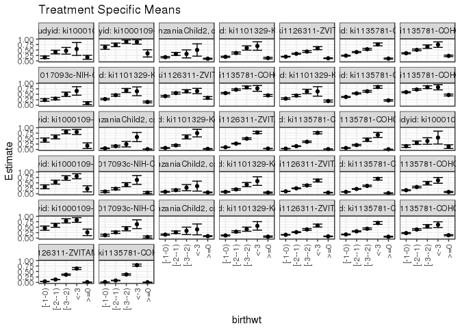

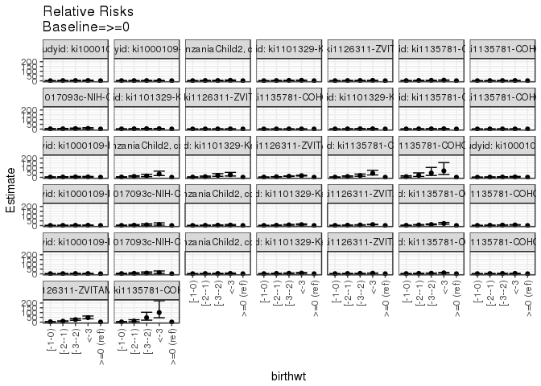

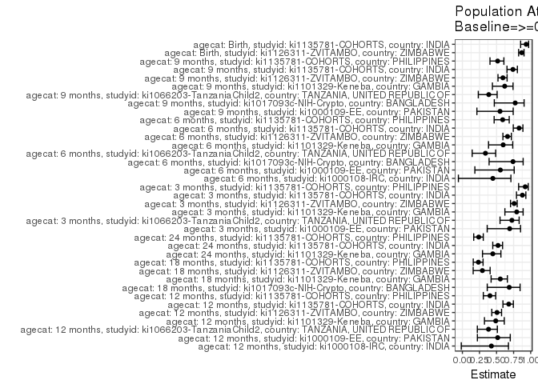

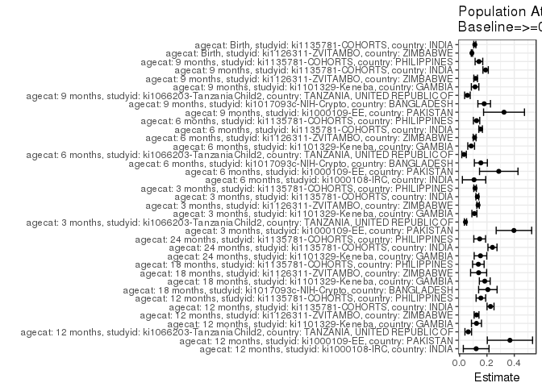

## Results Table

### Parameter: TSM

| agecat | studyid | country | intervention_level | baseline_level | estimate | ci_lower | ci_upper |
| --- | --- | --- | --- | --- | --- | --- | --- |
| Birth | ki1126311-ZVITAMBO | ZIMBABWE | >=0 | NA | 0.0135604 | 0.0095347 | 0.0175861 |
| Birth | ki1126311-ZVITAMBO | ZIMBABWE | <-3 | NA | 0.6361386 | 0.5892230 | 0.6830542 |
| Birth | ki1126311-ZVITAMBO | ZIMBABWE | [-3–2) | NA | 0.3566553 | 0.3292303 | 0.3840803 |
| Birth | ki1126311-ZVITAMBO | ZIMBABWE | [-2–1) | NA | 0.1330344 | 0.1215251 | 0.1445437 |
| Birth | ki1126311-ZVITAMBO | ZIMBABWE | [-1-0) | NA | 0.0468804 | 0.0414109 | 0.0523500 |
| Birth | ki1135781-COHORTS | INDIA | >=0 | NA | 0.0078947 | 0.0016023 | 0.0141872 |
| Birth | ki1135781-COHORTS | INDIA | <-3 | NA | 0.7922535 | 0.7450667 | 0.8394403 |
| Birth | ki1135781-COHORTS | INDIA | [-3–2) | NA | 0.3646922 | 0.3325383 | 0.3968462 |
| Birth | ki1135781-COHORTS | INDIA | [-2–1) | NA | 0.0886525 | 0.0769225 | 0.1003825 |
| Birth | ki1135781-COHORTS | INDIA | [-1-0) | NA | 0.0185784 | 0.0132593 | 0.0238974 |
| 3 months | ki1000109-EE | PAKISTAN | >=0 | NA | 0.1764706 | 0.0481586 | 0.3047826 |
| 3 months | ki1000109-EE | PAKISTAN | <-3 | NA | 0.8043478 | 0.6895546 | 0.9191411 |
| 3 months | ki1000109-EE | PAKISTAN | [-3–2) | NA | 0.8082192 | 0.7177841 | 0.8986542 |
| 3 months | ki1000109-EE | PAKISTAN | [-2–1) | NA | 0.5762712 | 0.4869926 | 0.6655498 |
| 3 months | ki1000109-EE | PAKISTAN | [-1-0) | NA | 0.4313725 | 0.3351291 | 0.5276160 |
| 3 months | ki1066203-TanzaniaChild2 | TANZANIA, UNITED REPUBLIC OF | >=0 | NA | 0.0162767 | 0.0083647 | 0.0241887 |
| 3 months | ki1066203-TanzaniaChild2 | TANZANIA, UNITED REPUBLIC OF | <-3 | NA | 0.5714286 | 0.3597256 | 0.7831315 |
| 3 months | ki1066203-TanzaniaChild2 | TANZANIA, UNITED REPUBLIC OF | [-3–2) | NA | 0.2444444 | 0.1188527 | 0.3700362 |
| 3 months | ki1066203-TanzaniaChild2 | TANZANIA, UNITED REPUBLIC OF | [-2–1) | NA | 0.1535836 | 0.1122908 | 0.1948764 |
| 3 months | ki1066203-TanzaniaChild2 | TANZANIA, UNITED REPUBLIC OF | [-1-0) | NA | 0.0541126 | 0.0395218 | 0.0687033 |
| 3 months | ki1101329-Keneba | GAMBIA | >=0 | NA | 0.0277778 | 0.0107973 | 0.0447582 |
| 3 months | ki1101329-Keneba | GAMBIA | <-3 | NA | 0.7500000 | 0.5767140 | 0.9232860 |
| 3 months | ki1101329-Keneba | GAMBIA | [-3–2) | NA | 0.5765766 | 0.4846327 | 0.6685205 |
| 3 months | ki1101329-Keneba | GAMBIA | [-2–1) | NA | 0.1900990 | 0.1558673 | 0.2243307 |
| 3 months | ki1101329-Keneba | GAMBIA | [-1-0) | NA | 0.0709838 | 0.0532173 | 0.0887503 |
| 3 months | ki1126311-ZVITAMBO | ZIMBABWE | >=0 | NA | 0.0429958 | 0.0344469 | 0.0515448 |
| 3 months | ki1126311-ZVITAMBO | ZIMBABWE | <-3 | NA | 0.7777778 | 0.7255032 | 0.8300523 |
| 3 months | ki1126311-ZVITAMBO | ZIMBABWE | [-3–2) | NA | 0.4972222 | 0.4606990 | 0.5337454 |
| 3 months | ki1126311-ZVITAMBO | ZIMBABWE | [-2–1) | NA | 0.2700730 | 0.2514850 | 0.2886610 |
| 3 months | ki1126311-ZVITAMBO | ZIMBABWE | [-1-0) | NA | 0.1037711 | 0.0941313 | 0.1134110 |

[output cut: 155 more lines]

### Parameter: E(Y)

| agecat | studyid | country | intervention_level | baseline_level | estimate | ci_lower | ci_upper |
| --- | --- | --- | --- | --- | --- | --- | --- |
| Birth | ki1126311-ZVITAMBO | ZIMBABWE | NA | NA | 0.1035430 | 0.1013626 | 0.1057234 |
| Birth | ki1135781-COHORTS | INDIA | NA | NA | 0.1191804 | 0.1148285 | 0.1235322 |
| 3 months | ki1000109-EE | PAKISTAN | NA | NA | 0.5737265 | 0.5541139 | 0.5933392 |
| 3 months | ki1066203-TanzaniaChild2 | TANZANIA, UNITED REPUBLIC OF | NA | NA | 0.0591350 | 0.0562013 | 0.0620688 |
| 3 months | ki1101329-Keneba | GAMBIA | NA | NA | 0.1358846 | 0.1290349 | 0.1427344 |
| 3 months | ki1126311-ZVITAMBO | ZIMBABWE | NA | NA | 0.1779985 | 0.1746847 | 0.1813122 |
| 3 months | ki1135781-COHORTS | INDIA | NA | NA | 0.1474547 | 0.1433881 | 0.1515214 |
| 3 months | ki1135781-COHORTS | PHILIPPINES | NA | NA | 0.1229248 | 0.1180130 | 0.1278365 |
| 6 months | ki1000108-IRC | INDIA | NA | NA | 0.2369077 | 0.2265417 | 0.2472737 |
| 6 months | ki1000109-EE | PAKISTAN | NA | NA | 0.5149051 | 0.4952185 | 0.5345918 |
| 6 months | ki1017093c-NIH-Crypto | BANGLADESH | NA | NA | 0.2097902 | 0.1997147 | 0.2198657 |
| 6 months | ki1066203-TanzaniaChild2 | TANZANIA, UNITED REPUBLIC OF | NA | NA | 0.0965174 | 0.0943862 | 0.0986486 |
| 6 months | ki1101329-Keneba | GAMBIA | NA | NA | 0.1415313 | 0.1365628 | 0.1464999 |
| 6 months | ki1126311-ZVITAMBO | ZIMBABWE | NA | NA | 0.1660012 | 0.1634092 | 0.1685932 |
| 6 months | ki1135781-COHORTS | INDIA | NA | NA | 0.1852739 | 0.1817623 | 0.1887855 |
| 6 months | ki1135781-COHORTS | PHILIPPINES | NA | NA | 0.2102102 | 0.2056644 | 0.2147560 |
| 9 months | ki1000109-EE | PAKISTAN | NA | NA | 0.5895317 | 0.5717324 | 0.6073309 |
| 9 months | ki1017093c-NIH-Crypto | BANGLADESH | NA | NA | 0.2322946 | 0.2222850 | 0.2423042 |
| 9 months | ki1066203-TanzaniaChild2 | TANZANIA, UNITED REPUBLIC OF | NA | NA | 0.1479390 | 0.1448418 | 0.1510363 |
| 9 months | ki1101329-Keneba | GAMBIA | NA | NA | 0.1828771 | 0.1775173 | 0.1882369 |
| 9 months | ki1126311-ZVITAMBO | ZIMBABWE | NA | NA | 0.1977778 | 0.1953051 | 0.2002504 |
| 9 months | ki1135781-COHORTS | INDIA | NA | NA | 0.2569522 | 0.2532573 | 0.2606470 |
| 9 months | ki1135781-COHORTS | PHILIPPINES | NA | NA | 0.2736132 | 0.2689717 | 0.2782547 |
| 12 months | ki1000108-IRC | INDIA | NA | NA | 0.2850000 | 0.2720170 | 0.2979830 |
| 12 months | ki1000109-EE | PAKISTAN | NA | NA | 0.7118644 | 0.6962128 | 0.7275160 |
| 12 months | ki1066203-TanzaniaChild2 | TANZANIA, UNITED REPUBLIC OF | NA | NA | 0.1651505 | 0.1610998 | 0.1692011 |
| 12 months | ki1101329-Keneba | GAMBIA | NA | NA | 0.2524752 | 0.2460094 | 0.2589411 |
| 12 months | ki1126311-ZVITAMBO | ZIMBABWE | NA | NA | 0.2443916 | 0.2417764 | 0.2470069 |
| 12 months | ki1135781-COHORTS | INDIA | NA | NA | 0.3330561 | 0.3288308 | 0.3372815 |
| 12 months | ki1135781-COHORTS | PHILIPPINES | NA | NA | 0.3852201 | 0.3803524 | 0.3900879 |
| 18 months | ki1017093c-NIH-Crypto | BANGLADESH | NA | NA | 0.3012618 | 0.2911869 | 0.3113367 |
| 18 months | ki1101329-Keneba | GAMBIA | NA | NA | 0.3312732 | 0.3242481 | 0.3382983 |
| 18 months | ki1126311-ZVITAMBO | ZIMBABWE | NA | NA | 0.4751025 | 0.4703186 | 0.4798865 |
| 18 months | ki1135781-COHORTS | PHILIPPINES | NA | NA | 0.5854753 | 0.5811554 | 0.5897952 |
| 24 months | ki1101329-Keneba | GAMBIA | NA | NA | 0.3428571 | 0.3366860 | 0.3490283 |
| 24 months | ki1135781-COHORTS | INDIA | NA | NA | 0.4603991 | 0.4563877 | 0.4644105 |
| 24 months | ki1135781-COHORTS | PHILIPPINES | NA | NA | 0.6152246 | 0.6111367 | 0.6193126 |

### Parameter: RR

| agecat | studyid | country | intervention_level | baseline_level | estimate | ci_lower | ci_upper |
| --- | --- | --- | --- | --- | --- | --- | --- |
| Birth | ki1126311-ZVITAMBO | ZIMBABWE | >=0 | >=0 | 1.000000 | 1.0000000 | 1.000000 |
| Birth | ki1126311-ZVITAMBO | ZIMBABWE | <-3 | >=0 | 46.911524 | 34.5487263 | 63.698183 |
| Birth | ki1126311-ZVITAMBO | ZIMBABWE | [-3–2) | >=0 | 26.301254 | 19.3549975 | 35.740432 |
| Birth | ki1126311-ZVITAMBO | ZIMBABWE | [-2–1) | >=0 | 9.810512 | 7.2011189 | 13.365443 |
| Birth | ki1126311-ZVITAMBO | ZIMBABWE | [-1-0) | >=0 | 3.457160 | 2.5129954 | 4.756060 |
| Birth | ki1135781-COHORTS | INDIA | >=0 | >=0 | 1.000000 | 1.0000000 | 1.000000 |
| Birth | ki1135781-COHORTS | INDIA | <-3 | >=0 | 100.352112 | 45.1240621 | 223.174642 |
| Birth | ki1135781-COHORTS | INDIA | [-3–2) | >=0 | 46.194347 | 20.7168753 | 103.003841 |
| Birth | ki1135781-COHORTS | INDIA | [-2–1) | >=0 | 11.229314 | 5.0056767 | 25.190900 |
| Birth | ki1135781-COHORTS | INDIA | [-1-0) | >=0 | 2.353258 | 1.0089312 | 5.488801 |
| 3 months | ki1000109-EE | PAKISTAN | >=0 | >=0 | 1.000000 | 1.0000000 | 1.000000 |
| 3 months | ki1000109-EE | PAKISTAN | <-3 | >=0 | 4.557971 | 2.1725517 | 9.562534 |
| 3 months | ki1000109-EE | PAKISTAN | [-3–2) | >=0 | 4.579909 | 2.1946406 | 9.557630 |
| 3 months | ki1000109-EE | PAKISTAN | [-2–1) | >=0 | 3.265537 | 1.5527087 | 6.867824 |
| 3 months | ki1000109-EE | PAKISTAN | [-1-0) | >=0 | 2.444444 | 1.1425424 | 5.229835 |
| 3 months | ki1066203-TanzaniaChild2 | TANZANIA, UNITED REPUBLIC OF | >=0 | >=0 | 1.000000 | 1.0000000 | 1.000000 |
| 3 months | ki1066203-TanzaniaChild2 | TANZANIA, UNITED REPUBLIC OF | <-3 | >=0 | 35.107139 | 19.0529667 | 64.688676 |
| 3 months | ki1066203-TanzaniaChild2 | TANZANIA, UNITED REPUBLIC OF | [-3–2) | >=0 | 15.018054 | 7.4035618 | 30.463978 |
| 3 months | ki1066203-TanzaniaChild2 | TANZANIA, UNITED REPUBLIC OF | [-2–1) | >=0 | 9.435792 | 5.4141476 | 16.444727 |
| 3 months | ki1066203-TanzaniaChild2 | TANZANIA, UNITED REPUBLIC OF | [-1-0) | >=0 | 3.324540 | 1.9068665 | 5.796192 |
| 3 months | ki1101329-Keneba | GAMBIA | >=0 | >=0 | 1.000000 | 1.0000000 | 1.000000 |
| 3 months | ki1101329-Keneba | GAMBIA | <-3 | >=0 | 27.000000 | 14.0459526 | 51.901072 |
| 3 months | ki1101329-Keneba | GAMBIA | [-3–2) | >=0 | 20.756757 | 11.0355186 | 39.041477 |
| 3 months | ki1101329-Keneba | GAMBIA | [-2–1) | >=0 | 6.843564 | 3.6184367 | 12.943262 |
| 3 months | ki1101329-Keneba | GAMBIA | [-1-0) | >=0 | 2.555417 | 1.3200436 | 4.946925 |
| 3 months | ki1126311-ZVITAMBO | ZIMBABWE | >=0 | >=0 | 1.000000 | 1.0000000 | 1.000000 |
| 3 months | ki1126311-ZVITAMBO | ZIMBABWE | <-3 | >=0 | 18.089605 | 14.6648413 | 22.314173 |
| 3 months | ki1126311-ZVITAMBO | ZIMBABWE | [-3–2) | >=0 | 11.564426 | 9.3555236 | 14.294865 |
| 3 months | ki1126311-ZVITAMBO | ZIMBABWE | [-2–1) | >=0 | 6.281375 | 5.0895091 | 7.752352 |
| 3 months | ki1126311-ZVITAMBO | ZIMBABWE | [-1-0) | >=0 | 2.413515 | 1.9379324 | 3.005810 |

[output cut: 155 more lines]

### Parameter: PAR

| agecat | studyid | country | intervention_level | baseline_level | estimate | ci_lower | ci_upper |
| --- | --- | --- | --- | --- | --- | --- | --- |
| Birth | ki1126311-ZVITAMBO | ZIMBABWE | >=0 | NA | 0.0899826 | 0.0854044 | 0.0945608 |
| Birth | ki1135781-COHORTS | INDIA | >=0 | NA | 0.1112856 | 0.1036349 | 0.1189363 |
| 3 months | ki1000109-EE | PAKISTAN | >=0 | NA | 0.3972560 | 0.2674537 | 0.5270582 |
| 3 months | ki1066203-TanzaniaChild2 | TANZANIA, UNITED REPUBLIC OF | >=0 | NA | 0.0428583 | 0.0344199 | 0.0512967 |
| 3 months | ki1101329-Keneba | GAMBIA | >=0 | NA | 0.1081069 | 0.0897969 | 0.1264168 |
| 3 months | ki1126311-ZVITAMBO | ZIMBABWE | >=0 | NA | 0.1350026 | 0.1258339 | 0.1441714 |
| 3 months | ki1135781-COHORTS | INDIA | >=0 | NA | 0.1295976 | 0.1191527 | 0.1400425 |
| 3 months | ki1135781-COHORTS | PHILIPPINES | >=0 | NA | 0.1131528 | 0.1039502 | 0.1223554 |
| 6 months | ki1000108-IRC | INDIA | >=0 | NA | 0.1057602 | 0.0203130 | 0.1912074 |
| 6 months | ki1000109-EE | PAKISTAN | >=0 | NA | 0.2863337 | 0.1456460 | 0.4270215 |
| 6 months | ki1017093c-NIH-Crypto | BANGLADESH | >=0 | NA | 0.1554424 | 0.1080031 | 0.2028816 |
| 6 months | ki1066203-TanzaniaChild2 | TANZANIA, UNITED REPUBLIC OF | >=0 | NA | 0.0325639 | 0.0160693 | 0.0490586 |
| 6 months | ki1101329-Keneba | GAMBIA | >=0 | NA | 0.0845513 | 0.0597904 | 0.1093122 |
| 6 months | ki1126311-ZVITAMBO | ZIMBABWE | >=0 | NA | 0.1097352 | 0.0991963 | 0.1202742 |
| 6 months | ki1135781-COHORTS | INDIA | >=0 | NA | 0.1537238 | 0.1405571 | 0.1668906 |
| 6 months | ki1135781-COHORTS | PHILIPPINES | >=0 | NA | 0.1240033 | 0.1007094 | 0.1472972 |
| 9 months | ki1000109-EE | PAKISTAN | >=0 | NA | 0.3248258 | 0.1752651 | 0.4743865 |
| 9 months | ki1017093c-NIH-Crypto | BANGLADESH | >=0 | NA | 0.1796630 | 0.1336275 | 0.2256986 |
| 9 months | ki1066203-TanzaniaChild2 | TANZANIA, UNITED REPUBLIC OF | >=0 | NA | 0.0571462 | 0.0367664 | 0.0775259 |
| 9 months | ki1101329-Keneba | GAMBIA | >=0 | NA | 0.1133119 | 0.0859285 | 0.1406953 |
| 9 months | ki1126311-ZVITAMBO | ZIMBABWE | >=0 | NA | 0.1173667 | 0.1040296 | 0.1307037 |
| 9 months | ki1135781-COHORTS | INDIA | >=0 | NA | 0.1901820 | 0.1705501 | 0.2098139 |
| 9 months | ki1135781-COHORTS | PHILIPPINES | >=0 | NA | 0.1413108 | 0.1133904 | 0.1692312 |
| 12 months | ki1000108-IRC | INDIA | >=0 | NA | 0.1210656 | 0.0271427 | 0.2149884 |
| 12 months | ki1000109-EE | PAKISTAN | >=0 | NA | 0.3681144 | 0.2025781 | 0.5336508 |
| 12 months | ki1066203-TanzaniaChild2 | TANZANIA, UNITED REPUBLIC OF | >=0 | NA | 0.0632087 | 0.0390039 | 0.0874136 |
| 12 months | ki1101329-Keneba | GAMBIA | >=0 | NA | 0.1233461 | 0.0867418 | 0.1599505 |
| 12 months | ki1126311-ZVITAMBO | ZIMBABWE | >=0 | NA | 0.1239455 | 0.1063541 | 0.1415369 |
| 12 months | ki1135781-COHORTS | INDIA | >=0 | NA | 0.2261596 | 0.2006586 | 0.2516606 |
| 12 months | ki1135781-COHORTS | PHILIPPINES | >=0 | NA | 0.1555381 | 0.1205384 | 0.1905379 |
| 18 months | ki1017093c-NIH-Crypto | BANGLADESH | >=0 | NA | 0.2066672 | 0.1391797 | 0.2741548 |
| 18 months | ki1101329-Keneba | GAMBIA | >=0 | NA | 0.1839378 | 0.1444014 | 0.2234741 |
| 18 months | ki1126311-ZVITAMBO | ZIMBABWE | >=0 | NA | 0.1391025 | 0.0803396 | 0.1978654 |
| 18 months | ki1135781-COHORTS | PHILIPPINES | >=0 | NA | 0.1371358 | 0.0950365 | 0.1792351 |
| 24 months | ki1101329-Keneba | GAMBIA | >=0 | NA | 0.1527163 | 0.1066467 | 0.1987859 |
| 24 months | ki1135781-COHORTS | INDIA | >=0 | NA | 0.2403663 | 0.2072173 | 0.2735152 |
| 24 months | ki1135781-COHORTS | PHILIPPINES | >=0 | NA | 0.1470165 | 0.1038841 | 0.1901490 |

### Parameter: PAF

| agecat | studyid | country | intervention_level | baseline_level | estimate | ci_lower | ci_upper |
| --- | --- | --- | --- | --- | --- | --- | --- |
| Birth | ki1126311-ZVITAMBO | ZIMBABWE | >=0 | NA | 0.8690362 | 0.8236385 | 0.9027479 |
| Birth | ki1135781-COHORTS | INDIA | >=0 | NA | 0.9337581 | 0.8528876 | 0.9701725 |
| 3 months | ki1000109-EE | PAKISTAN | >=0 | NA | 0.6924134 | 0.3630691 | 0.8514603 |
| 3 months | ki1066203-TanzaniaChild2 | TANZANIA, UNITED REPUBLIC OF | >=0 | NA | 0.7247536 | 0.5513308 | 0.8311438 |
| 3 months | ki1101329-Keneba | GAMBIA | >=0 | NA | 0.7955782 | 0.6225055 | 0.8893010 |
| 3 months | ki1126311-ZVITAMBO | ZIMBABWE | >=0 | NA | 0.7584483 | 0.7050559 | 0.8021752 |
| 3 months | ki1135781-COHORTS | INDIA | >=0 | NA | 0.8788975 | 0.7922978 | 0.9293901 |
| 3 months | ki1135781-COHORTS | PHILIPPINES | >=0 | NA | 0.9205043 | 0.8235429 | 0.9641864 |
| 6 months | ki1000108-IRC | INDIA | >=0 | NA | 0.4464193 | -0.0585009 | 0.7104853 |
| 6 months | ki1000109-EE | PAKISTAN | >=0 | NA | 0.5560902 | 0.1824824 | 0.7589582 |
| 6 months | ki1017093c-NIH-Crypto | BANGLADESH | >=0 | NA | 0.7409420 | 0.3912724 | 0.8897519 |
| 6 months | ki1066203-TanzaniaChild2 | TANZANIA, UNITED REPUBLIC OF | >=0 | NA | 0.3373891 | 0.1434660 | 0.4874071 |
| 6 months | ki1101329-Keneba | GAMBIA | >=0 | NA | 0.5974032 | 0.3828599 | 0.7373624 |
| 6 months | ki1126311-ZVITAMBO | ZIMBABWE | >=0 | NA | 0.6610508 | 0.5933010 | 0.7175144 |
| 6 months | ki1135781-COHORTS | INDIA | >=0 | NA | 0.8297112 | 0.7452822 | 0.8861553 |
| 6 months | ki1135781-COHORTS | PHILIPPINES | >=0 | NA | 0.5899015 | 0.4649864 | 0.6856513 |
| 9 months | ki1000109-EE | PAKISTAN | >=0 | NA | 0.5509896 | 0.2125108 | 0.7439833 |
| 9 months | ki1017093c-NIH-Crypto | BANGLADESH | >=0 | NA | 0.7734275 | 0.4673305 | 0.9036267 |
| 9 months | ki1066203-TanzaniaChild2 | TANZANIA, UNITED REPUBLIC OF | >=0 | NA | 0.3862820 | 0.2330834 | 0.5088778 |
| 9 months | ki1101329-Keneba | GAMBIA | >=0 | NA | 0.6196068 | 0.4397750 | 0.7417127 |
| 9 months | ki1126311-ZVITAMBO | ZIMBABWE | >=0 | NA | 0.5934269 | 0.5212266 | 0.6547392 |
| 9 months | ki1135781-COHORTS | INDIA | >=0 | NA | 0.7401455 | 0.6530269 | 0.8053902 |
| 9 months | ki1135781-COHORTS | PHILIPPINES | >=0 | NA | 0.5164619 | 0.4041919 | 0.6075765 |
| 12 months | ki1000108-IRC | INDIA | >=0 | NA | 0.4247915 | -0.0163648 | 0.6744625 |
| 12 months | ki1000109-EE | PAKISTAN | >=0 | NA | 0.5171131 | 0.2196915 | 0.7011698 |
| 12 months | ki1066203-TanzaniaChild2 | TANZANIA, UNITED REPUBLIC OF | >=0 | NA | 0.3827341 | 0.2189252 | 0.5121886 |
| 12 months | ki1101329-Keneba | GAMBIA | >=0 | NA | 0.4885474 | 0.3231557 | 0.6135244 |
| 12 months | ki1126311-ZVITAMBO | ZIMBABWE | >=0 | NA | 0.5071595 | 0.4303567 | 0.5736072 |
| 12 months | ki1135781-COHORTS | INDIA | >=0 | NA | 0.6790434 | 0.5937748 | 0.7464138 |
| 12 months | ki1135781-COHORTS | PHILIPPINES | >=0 | NA | 0.4037643 | 0.3062811 | 0.4875489 |
| 18 months | ki1017093c-NIH-Crypto | BANGLADESH | >=0 | NA | 0.6860054 | 0.3637361 | 0.8450444 |
| 18 months | ki1101329-Keneba | GAMBIA | >=0 | NA | 0.5552449 | 0.4203376 | 0.6587547 |
| 18 months | ki1126311-ZVITAMBO | ZIMBABWE | >=0 | NA | 0.2927842 | 0.1578692 | 0.4060850 |
| 18 months | ki1135781-COHORTS | PHILIPPINES | >=0 | NA | 0.2342299 | 0.1590116 | 0.3027206 |
| 24 months | ki1101329-Keneba | GAMBIA | >=0 | NA | 0.4454225 | 0.2944423 | 0.5640950 |
| 24 months | ki1135781-COHORTS | INDIA | >=0 | NA | 0.5220824 | 0.4448495 | 0.5885706 |
| 24 months | ki1135781-COHORTS | PHILIPPINES | >=0 | NA | 0.2389640 | 0.1656701 | 0.3058192 |